# Stats 20, 23C – Homework 1

Daren Sathasivam – 306229580

11/08/23

## Question 1

### (a)

“**Sometimes you have to make the hardest climbs to see the most beautiful sunrise.** I read that once on an old lady’s decorative pillow, but it is really how I feel today. I’ve climbed a very weird and rocky mountain, and it was a pain in the ass, and my legs are tired, and I’m starving. But *the sun is rising over a sea of love and waffles and possibility.* So *I’m just gonna relax and take a deep breath and enjoy this view for as long as I possibly can.*” - Leslie Knope (from **Parks and Recreation**)

### (b)

| Homework | Midterm | Final Exam | Final Project |
| --- | --- | --- | --- |
| 18% | 30% | 40% | 12% |

### (c)

- 2022
  - Spring
    - CS 2: Intro to Data Structures
    - ENG 1CH: Honors Critical Thinking/Composition
    - PHYS 1A: Mechanics of Solids
    - MATH 191: Single Var Calc/Analyt Geometry II
  - Summer
    - AHIS 102AH: Honors History West: Prehistoric-Gothic
    - COMS 120: Argumentation and Debate
  - Fall
    - CS30: Advanced Programming in C++
    - Math 220: Multi-Variable Calculus
    - PHYS 1C: Electricity/Magnetism
  - Winter
    - Math 150: Elementary Statistics w/ Probability
- 2023
  - Spring
    - CS 3: Computer Programming in Java
    - CS 12: Programming Using Php, Js, Xhtml
    - Math 270: Differential Equations and Linear Algebra
    - HDEV 110: Strategies for Creating Success
  - Fall
    - Stats 20
    - Stats 100A
    - International Development Studies 1

### (d)

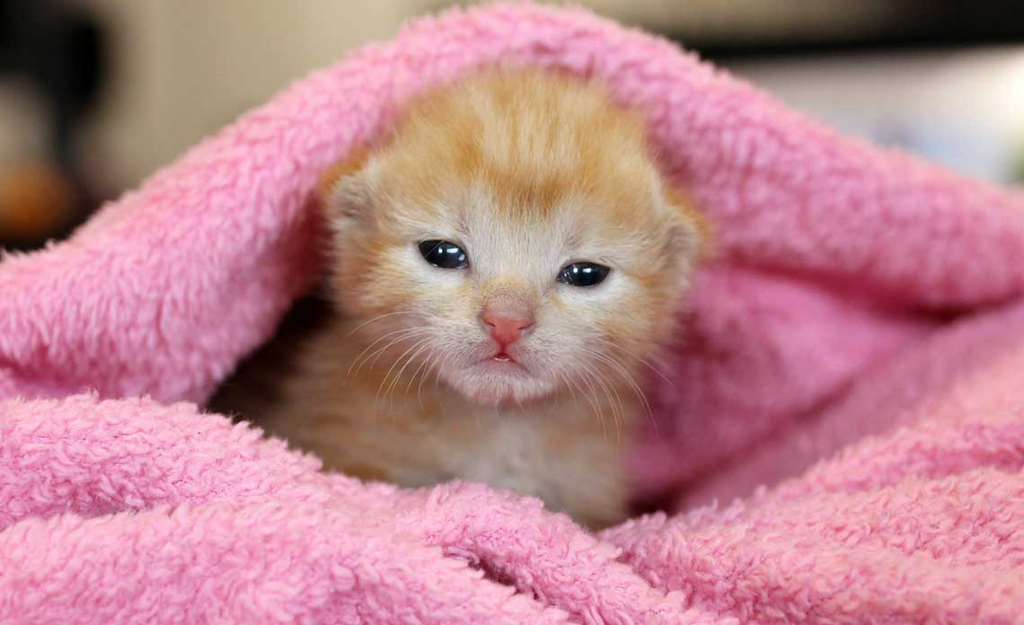

Sample kitten from: https://www.operationkindness.org/wp-content/uploads/blog-kitten-nursery-operation-kindness.jpg

## Question 2

### (a)

The relevance of these videos in context to the class would be instructions on how to write and utilize R programming. Some steps may seem easy enough to be self-explanatory but may be confusing to those who are new to the language. If it seems as if the professor, TAs, or peers are overly explaining a solution, it is so that everyone can understand rather than assuming everyone understands certain steps.

### (b)

1. Turn on stove to roughly medium heat.
2. Place pan onto stove-top that is being used/on.
3. Pour a teaspoon of oil into pan.
4. Grab two slices of bread from the pantry.
5. Place both slices onto the pan.
6. Grab your choice of cheese.
7. Take out cheese from container and place desired amount onto both slices of bread.
8. Once the slices of bread and cheese have melted/cooked to the desired amount, take the slices and place them onto a plate(can be found in your kitchen).
9. Place one slice on top of the other and squeeze lightly. 10. Cut the grilled cheese in your desired fashion.
10. Consume the grilled cheese.
11. Clean up kitchen and place ingredients back into their original place.

## Question 3

### (a)

```r
(6)^8 / (16)^5
```

```
## [1] 1.601807
```

```r
101^(-8 / 7)
```

```
## [1] 0.005120908
```

```r
8 + (3 * pi) - 3 + (4 / 2) * (-1)
```

```
## [1] 12.42478
```

1. 1.601807
2. 0.005120908
3. 12.42478

### (b)

```r
log(54, base = 3)
```

```
## [1] 3.63093
```

```r
exp(exp(sqrt(2)))
```

```
## [1] 61.14514
```

```r
(exp(pi) + exp(-pi)) / (2)
```

```
## [1] 11.59195
```

1. 3.63093
2. 61.14514
3. 11.59195

### (c)

```r
119 %/% 25
```

```
## [1] 4
```

```r
119 %% 25
```

```
## [1] 19
```

1. 4
2. 19

## Question 4

### (a)

```r
vol_1 <- (4 / 3) * pi * (1^3)
vol_1
```

```
## [1] 4.18879
```

```r
vol_4 <- (4 / 3) * pi * (4^3)
vol_4
```

```
## [1] 268.0826
```

1. 4.18879
2. 268.0826

### (b)

```r
r <- 1 # Issue with knitting if this is not present
vol_sphere <- function(r = 1) { #default radius to 1 unit
  (4 / 3) * pi * (r^3)
}
vol_sphere(r)
```

```
## [1] 4.18879
```

### (c)

```r
vol_sphere <- function(r = 1) {
  (4 / 3) * pi * (r^3)
}
vol_sphere(1)
```

```
## [1] 4.18879
```

```r
vol_sphere(4)
```

```
## [1] 268.0826
```

1. 4.18879 matches previous solution
2. 268.0826 matches previous solution

## Question 5

### (a)

```r
z_prop <- function(x, n, p0) {
  ## (p^ - p_0) / sqrt((p_0*(1 - p_0)) / n)
  sample_prop <- x / n # Calculate p^(sample proportion)
  std_err <- sqrt((p0 * (1 - p0)) / n) # Calculate denom(standard error)
  (sample_prop - p0) / std_err # Calculate z prop eqn
}
```

Sample proportion $\hat{p}$ is related to the input arguments by being the recorded proportion which is different from the hypothesized proportion. In order to get a value for the $\hat{p}$ (sample proportion), the number of observed successed is diveded by the number of trials ran.

### (b)

```r
z_prop <- function(x, n, p0) {
  ## (p^ - p_0) / sqrt((p_0*(1 - p_0)) / n)
  sample_prop <- x / n # Calculate p^(sample proportion)
  std_err <- sqrt((p0 * (1 - p0)) / n) # Calculate denom(standard error)
  (sample_prop - p0) / std_err # Calculate z prop eqn
}
z_prop(10, 13, 0.6)
```

```
## [1] 1.245505
```

### (c)

The z-statistic from b is 1.245505, which indicates a deviation from the mean. Depending on whether or not the test is one-tail or two-tail, the significance level can be determined by this z-statstic value. The individual value is greater than the mean in this case due to it being a positive value.

### (d)

```r
z_prop <- function(x, n, p0) {
  ## (p^ - p_0) / sqrt((p_0*(1 - p_0)) / n)
  sample_prop <- x / n # Calculate p^(sample proportion)
  std_err <- sqrt((p0 * (1 - p0)) / n) # Calculate denom(standard error)
  (sample_prop - p0) / std_err # Calculate z prop eqn
}
z_prop(30, 39, 0.6)
```

```
## [1] 2.157277
```

Although the sample proportion remained constant, the z-statistic has changed because the number of trials has tripled. The increase in the number of trials has made the standard error smaller which results in a bigger z-statistic.

## Question 6

### (a)

```r
# lease calculating function
lease_calc <- function(msrp, price, down, n = 36, res = 0.60, mf = 0.001, tax = 0.095) {
  cap_cost <- price - down
  res_val <- msrp * res
  mo_depr <- (cap_cost - res_val) / n
  mo_charge <- (cap_cost + res_val) * mf

  sub_total <- mo_depr + mo_charge
  total <- sub_total + (sub_total * tax)

  # return(total) not allowed
  total
}
```

### (b)

```r
# lease calculating function
lease_calc <- function(msrp, price, down, n = 36, res = 0.60, mf = 0.001, tax = 0.095) {
  cap_cost <- price - down
  res_val <- msrp * res
  mo_depr <- (cap_cost - res_val) / n
  mo_charge <- (cap_cost + res_val) * mf

  sub_total <- mo_depr + mo_charge
  total <- sub_total + (sub_total * tax)

  # return(total) not allowed
  total
}

lease_calc(31495, 29895, 2500, 36, 0.52, 0.0016, 0.095)
```

```
## [1] 411.8079
```

Monthly lease payment for the car above is $411.81

## Question 7

### (a)

The minimum number of coins needed to get 47 cents is 5 coins. Using 1 quarter, 2 dimes, and 2 pennies which totals to 5 coins and 47 cents.

### (b)

- Check number of quarters
  - Get number of quarters
  - Get remainder of cents
    - If there is a remainder, check other coins
- Check number of dimes
  - Get number of dimes
  - Get remainder of cents
    - If there is a remainder, check other coins
- Check number of nickels
  - Get number of nickels
  - Get remainder of cents
    - If there is a remainder, check number of pennies
- Check number of pennies
  - Get number of pennies
- Add number of coins together
  - Output number of coins

### (c)

```r
get_minimum_coins <- function(cents) {
  no_quart <- cents %/% 25
  remainder <- cents %% 25

  no_dimes <- remainder %/% 10
  remainder <- remainder %% 10

  no_nicks <- remainder %/% 5
  remainder <- remainder %% 5

  no_penns <- remainder %/% 1

  whole <- no_quart + no_dimes + no_nicks + no_penns
  # return(whole) not allowed
  whole
}

 # --- With For-Loop but future ch ---
# get_minimum_coins <- function(cents){
#   coin_vals <- c(25, 10, 5, 1)
#
#   no_coins <- 0
#   for(coin in coin_vals){ # Iterate through each coin
#     no_coins <- no_coins + (cents %/% coin) # Get the number of coins
#     cents <- cents %% coin # Update remainder
#   }
#   return(no_coins)
# }
```

### (d)

```r
get_minimum_coins(31) # Ans = 3 coins
```

```
## [1] 3
```

```r
get_minimum_coins(48) # Ans = 6 coins
```

```
## [1] 6
```

```r
get_minimum_coins(139) # Ans = 10 coins
```

```
## [1] 10
```

1. 3
2. 6
3. 10

### (e)

```r
get_minimum_coins(94)
```

```
## [1] 9
```

```r
get_minimum_coins(99)
```

```
## [1] 9
```

The most coins possible while staying under 100 cents would be 94 and 99 cents. Both require 9 coins where three quarters, one dime, one nickel, and four pennies or three quarters, two dimes, and four pennies are used. The get_minimum_coins() function also displays that both answers will require 9 coins.

## Question 8

```r
x <- 3
y <- 4
exp1 <- function() {
  x^y
}
exp2 <- function(x = 2) {
  x^y
}
exp_y <- function(x) {
  function(y) {
    x^y
  }
}
```

### (a)

In the the r-block, x and y are first initialzied to values. exp1 does not change any of the values but in exp2’s function argument, the x is initialized to 2 instead of 3. This results in exp2 being 16 instead of 81.

### (b)

exp_y() does not throw a code as it is calling a function within its own function. The output is the function(y) defined within the exp_y() function which is displayed in addition to the message: “<environment: random location/address>”.

### (c)

```r
# exp_y(x)(y)
exp_y(15)(4)
```

```
## [1] 50625
```

exp_y(15)(4) = 50625